# Metal Health in Tech Work Place

Aditi

1/5/2018

## **Executive Summary**

This [mental health in tech workplace dataset](https://www.kaggle.com/osmi/mental-health-in-tech-survey/data) is downloaded from Kaggle, which is a survey in 2014 with 27 variables and 1259 observations, focusing on mental health and disorders in tech workplace. Main question I’m asking is what factors contribute the most to accept treatment for mental disorders.

## **Description and Exploratory Data Analysis**

### All the variables of the survey

[click here for source](https://www.kaggle.com/osmi/mental-health-in-tech-survey)

- **Timestampe**
- **Age**
- **Gender**
- **Country**
- **state**: If you live in the United States, which state or territory do you live in?
- **self_employed**: Are you self-employed?
- **family_history**: Do you have a family history of mental illness?
- **treatment**: Have you sought treatment for a mental health condition?
- **work_interfere**: If you have a mental health condition, do you feel that it interferes with your work?
- **no_employees**: How many employees does your company or organization have?
- **remote_work**: Do you work remotely (outside of an office) at least 50% of the time?
- **tech_company**: Is your employer primarily a tech company/organization?
- **benefits**: Does your employer provide mental health benefits?
- **care_options**: Do you know the options for mental health care your employer provides?
- **wellness_program**: Has your employer ever discussed mental health as part of an employee wellness program?
- **seek_help**: Does your employer provide resources to learn more about mental health issues and how to seek help?
- **anonymity**: Is your anonymity protected if you choose to take advantage of mental health or substance abuse treatment resources?
- **leave**: How easy is it for you to take medical leave for a mental health condition?
- **mental_health_consequence**: Do you think that discussing a mental health issue with your employer would have negative consequences?
- **phys_health_consequence**: Do you think that discussing a physical health issue with your employer would have negative consequences?
- **coworkers**: Would you be willing to discuss a mental health issue with your coworkers?
- **supervisor**: Would you be willing to discuss a mental health issue with your direct supervisor(s)?
- **mental_health_interview**: Would you bring up a mental health issue with a potential employer in an interview?
- **phys_health_interview**: Would you bring up a physical health issue with a potential employer in an interview?
- **mental_vs_physical**: Do you feel that your employer takes mental health as seriously as physical health?
- **obs_consequence**: Have you heard of or observed negative consequences for coworkers with mental health conditions in your workplace?
- **comments**: Any additional notes or comments

### Exploratory data analysis

Using data visualization to explore four questions. (1) How does accepting treatment or not differ by employees size? (2) How does accepting treatment or not differ by company types? (3) How does help seeking differ by gender? (4) How does accepting treatment vary across the world? Check the plots below.

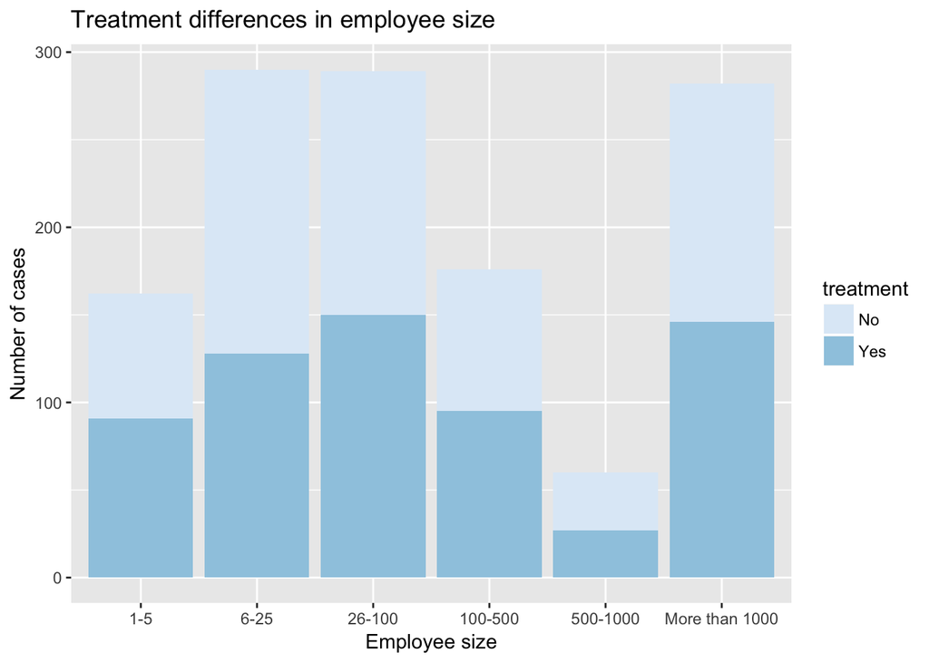

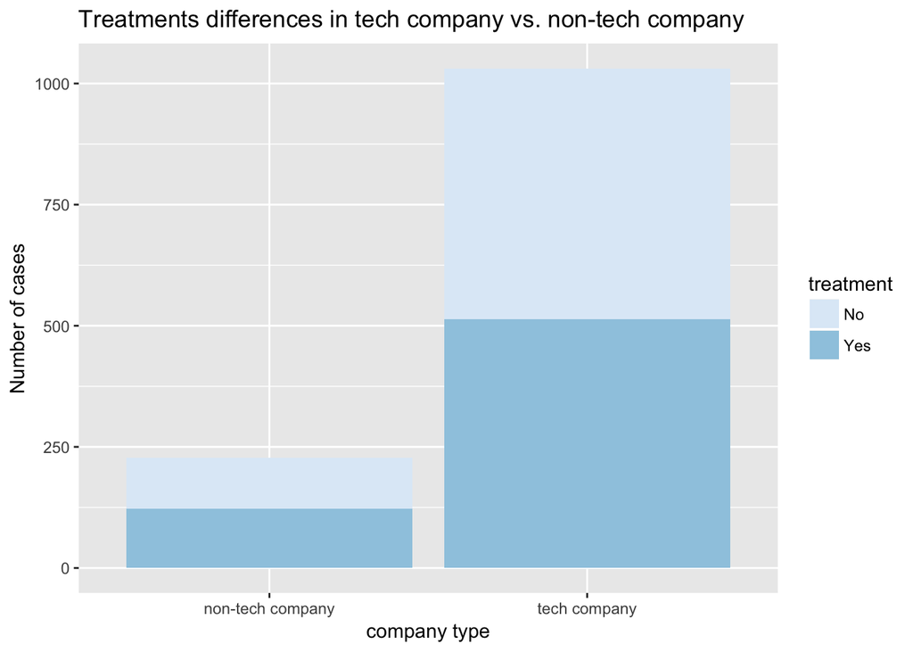

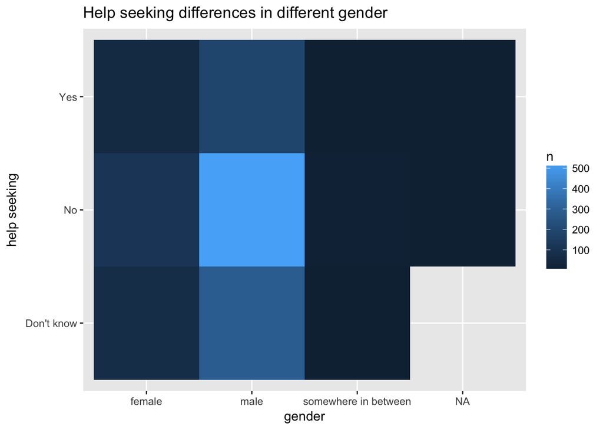

```
## 28 codes from your data successfully matched countries in the map
## 0 codes from your data failed to match with a country code in the map
## 215 codes from the map weren't represented in your data
```

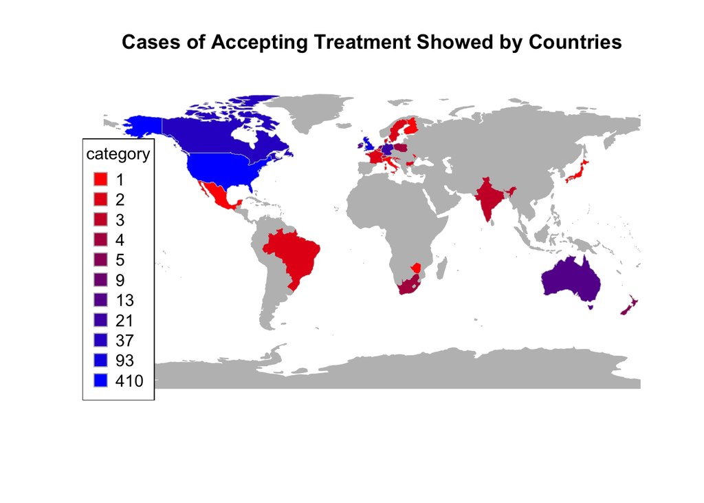

### Missing Data Checking

Two ways to show missing values, the actual number of cases and visualization. According to the output, `comments`, `state` and `work_interfere` have the most frequent missing datapoints. Hence, they won’t enter later regression analysis.

```
##                 Timestamp                       Age
##                         0                         0
##                    Gender                   Country
##                         0                         0
##                     state             self_employed
##                       515                        18
##            family_history                 treatment
##                         0                         0
##            work_interfere              no_employees
##                       264                         0
##               remote_work              tech_company
##                         0                         0
##                  benefits              care_options
##                         0                         0
##          wellness_program                 seek_help
##                         0                         0
##                 anonymity                     leave
##                         0                         0
## mental_health_consequence   phys_health_consequence
##                         0                         0
##                 coworkers                supervisor
##                         0                         0
##   mental_health_interview     phys_health_interview
##                         0                         0
##        mental_vs_physical           obs_consequence
##                         0                         0
##                  comments
##                      1096
```

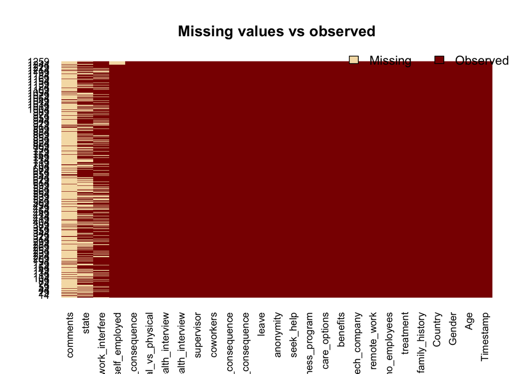

## **Hypotheses and Statistical Analysis**

### Correlation Analysis

```
##
## Call: xtabs(formula = ~treatment + family_history, data = mental_new)
## Number of cases in table: 1259
## Number of factors: 2
## Test for independence of all factors:
##  Chisq = 179.81, df = 1, p-value = 5.325e-41
##                     X^2 df P(> X^2)
## Likelihood Ratio 185.71  1        0
## Pearson          179.81  1        0
##
## Phi-Coefficient   : 0.378
## Contingency Coeff.: 0.354
## Cramer's V        : 0.378
```

- **Hypothesis 2**:
  - H0: Whether accepting `treatment` is independent of `benefits`.
  - H1: Whether accepting `treatment` is associated with `benefits`.
- **Result 2**:  
  With P-value < .01, we can reject the null hypothesis. That is to say, there is some association between `treatment` and `benefits`.

```
##
## Call: xtabs(formula = ~treatment + benefits, data = mental_new)
## Number of cases in table: 1259
## Number of factors: 2
## Test for independence of all factors:
##  Chisq = 64.84, df = 2, p-value = 8.327e-15
##                     X^2 df   P(> X^2)
## Likelihood Ratio 65.644  2 5.5511e-15
## Pearson          64.839  2 8.3267e-15
##
## Phi-Coefficient   : NA
## Contingency Coeff.: 0.221
## Cramer's V        : 0.227
```

### Logistic Regression

#### Model Fitting and Model Reduction

**Regression Results**

|  | *Dependent variable:* |
| --- | --- |
|  | treatment_or_not |
| gendermale | -0.727*** |
|  | (0.252) |
| gendersomewhere in between | -1.131 |
|  | (0.801) |
| family_historyYes | 1.677*** |
|  | (0.205) |
| benefitsNo | -0.216 |
|  | (0.282) |
| benefitsYes | 0.662** |
|  | (0.257) |
| care_optionsNot sure | -0.021 |
|  | (0.250) |
| care_optionsYes | 1.187*** |
|  | (0.255) |
| leaveSomewhat difficult | 1.198*** |
|  | (0.359) |
| leaveSomewhat easy | 0.059 |
|  | (0.257) |
| leaveVery difficult | 0.377 |
|  | (0.414) |
| leaveVery easy | -0.042 |
|  | (0.288) |
| mental_health_consequenceNo | -0.458** |
|  | (0.222) |
| mental_health_consequenceYes | 0.095 |
|  | (0.269) |
| Constant | -0.616* |
|  | (0.333) |
| Observations | 628 |
| Log Likelihood | -332.269 |
| Akaike Inf. Crit. | 692.539 |
| *Note:* | p<0.1; p<0.05; p<0.01 |

At first, all interested variables entered logistic regression, results showed that `Gender-male`(p<.01), `family_history-Yes`(p<.001), `benefits-Yes`(p<.05), `care_options-Yes`(p<.001), `leaveSomewhat difficult`(p<.01), `mental_health_consequence-No`(p<.05) and `coworkers-Yes`(p<.05) are statistically significant associated with whether accepting `treatment` or not. After **Model Reduction**, `gender-male`(p<.01), `family_history-Yes`(p<.001), `benefits-Yes`(p<.05), `care_options-Yes`(p<.001), `leaveSomewhat difficult`(p<.001), `mental_health_consequence-No`(p<.05) remained statistically significant.

#### Odds Ratios and Confidence Intervals

|  | OR | 2.5 % | 97.5 % |
| --- | --- | --- | --- |
| (Intercept) | 0.5398882 | 0.2796936 | 1.0351853 |
| gendermale | 0.4831779 | 0.2926878 | 0.7882109 |
| gendersomewhere in between | 0.3226781 | 0.0713485 | 1.7860622 |
| family_historyYes | 5.3477800 | 3.6018778 | 8.0390562 |
| benefitsNo | 0.8060689 | 0.4625789 | 1.4001083 |
| benefitsYes | 1.9378929 | 1.1722422 | 3.2133856 |
| care_optionsNot sure | 0.9788977 | 0.5994579 | 1.5970319 |
| care_optionsYes | 3.2765906 | 1.9970371 | 5.4319899 |
| leaveSomewhat difficult | 3.3142638 | 1.6616461 | 6.8256269 |
| leaveSomewhat easy | 1.0609680 | 0.6404154 | 1.7537777 |
| leaveVery difficult | 1.4581213 | 0.6470147 | 3.2953448 |
| leaveVery easy | 0.9585259 | 0.5424383 | 1.6822004 |
| mental_health_consequenceNo | 0.6324845 | 0.4084286 | 0.9759218 |
| mental_health_consequenceYes | 1.0999428 | 0.6484849 | 1.8667955 |

### Goodness of Fit

|  | Df | Deviance | Resid. Df | Resid. Dev | Pr(>Chi) |
| --- | --- | --- | --- | --- | --- |
| NULL | NA | NA | 627 | 870.4909 | NA |
| gender | 2 | 33.970904 | 625 | 836.5200 | 0.0000000 |
| family_history | 1 | 91.046610 | 624 | 745.4734 | 0.0000000 |
| benefits | 2 | 33.947290 | 622 | 711.5261 | 0.0000000 |
| care_options | 2 | 24.258218 | 620 | 687.2679 | 0.0000054 |
| leave | 4 | 16.827233 | 616 | 670.4407 | 0.0020882 |
| mental_health_consequence | 2 | 5.901958 | 614 | 664.5387 | 0.0522885 |

```
##          llh      llhNull           G2     McFadden         r2ML
## -332.2693658 -436.6541519  208.7695722    0.2390560    0.2828252
##         r2CU
##    0.3765586
```

Analyzing the table of deviance, adding `gender`, `family_history`, `benefits`, `care_options` and `leave` significntly reduces the residual deviance, and the other variables seem to improve the model less (with larger p-value). McFadden R^2 (0.239) is between 0.2-0.4, which represent an excellent model fit.

### Predictive Ability of the Model

```
## [1] "Accuracy 0.659235668789809"
```

The 0.66 accuracy on the test set is a moderate result.

### ROC curve and AUC

ROC curve and AUC (area under the curve) are perfromance measurements for a binary classifier. The ROC is a curve generated by plotting the true positive rate (TPR) against the false positive rate (FPR) at various threshold settings. AUC closer to 1 than to 0.5 indicates a model with good predictive ability. According to plot, our model has good predictive ability.

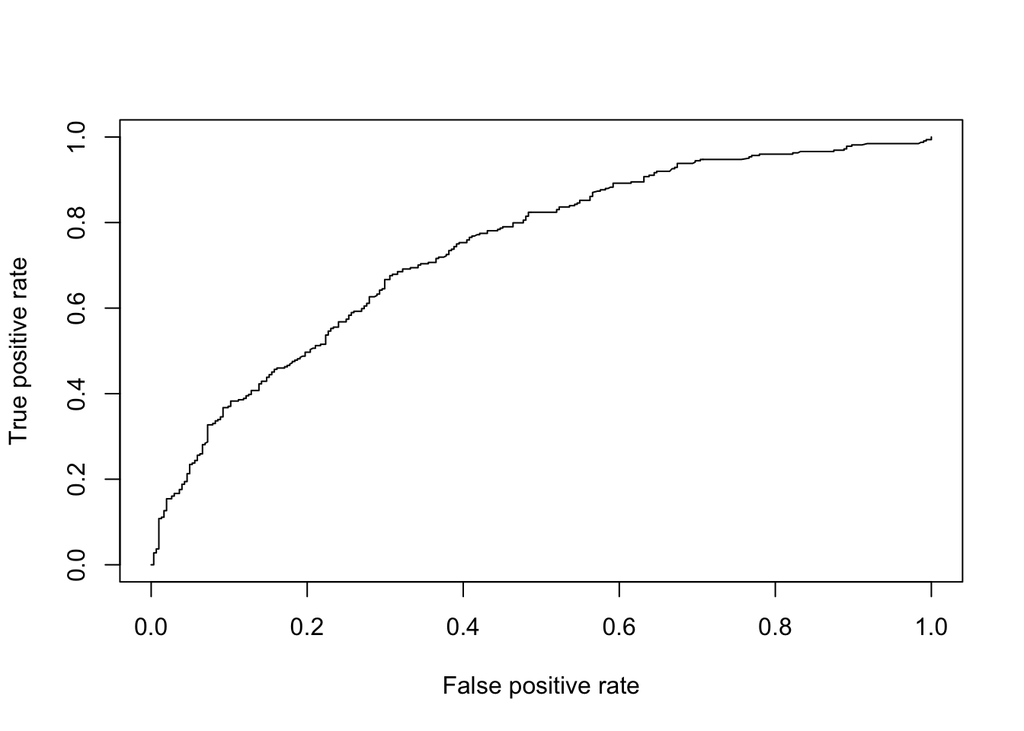

```
## [1] 0.7391772
```